# REST API

## What is REST API?

An API is an **Application Programming Interface**. It is a set of rules that allow programs to talk to each other. The developer creates the API on the server and allows the client to talk to it.

REST determines how the API looks like. It stands for **Representational State Transfer**. It is a set of rules that developers follow when they create their API. One of these rules states that you should be able to get a piece of data (called a resource) when you link to a specific URL.

- URL is called a **request**
- The data sent back to you is called a **response**.

### How does a request look like?

The request has 4 parts:

1. Endpoint
2. Method
3. Headers
4. Data (or body)

## 1) The Endpoint

(or route) is the url you request for. It follows this structure: *root-endpoint/path*

### 1.1) Structure of Endpoints

The **root-endpoint** is the starting point of the API you’re requesting from.

- The root-endpoint of Github’s API is https://api.github.com
- The root-endpoint of Twitter’s API is https://api.twitter.com

The **path** determines the resource you’re requesting for. e.g. /tag/javascript/

- https://www.smashingmagazine.com/ is the root-endpoint and /tag/javascript is the path.

To understand what paths are available to you, you need to look through the API documentation.

For example, let’s say you want to get a list of repositories by a certain user through Github’s API. The docs tells you to use the the following path to do so:

- /users/:username/repos

(Any colons (:) on a path denotes a variable. You should replace these values with actual values of when you send your request)

- e.g. The endpoint to get a list of my repos on Github is this: https://api.github.com/users/sknodler/repos

The final part of an endpoint is query parameters. Technically, query parameters are not part of the REST architecture, but you’ll see lots of APIs use them.

They always begin with a question mark (?). Each parameter pair is then separated with an ampersand (&), like this:

- ?query1=value1&query2=value2

#### Example:

If you’d like to get a list the repositories that I pushed to recently, you can set sort to push:

- https://api.github.com/users/sknoedler/repos?sort=pushed

### 1.2) Testing Endpoints With Curl

You can send a request with any programming language. JavaScript users can use methods like the Fetch API and jQuery’s Ajax method; Ruby users can use Ruby’s Net::HTTP class, Python users can use Python Requests;

For this article, we’ll use the command line utility called cURL.

#### Example:

- curl https://api.github.com

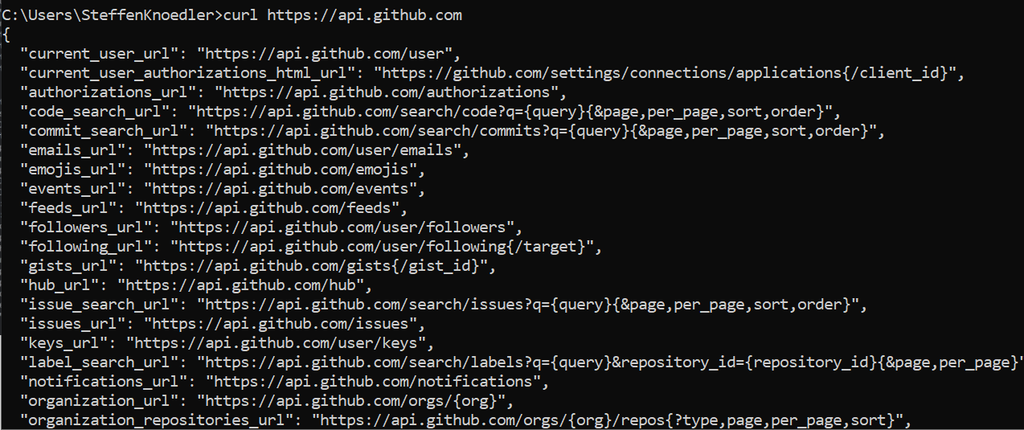

If you wish to include query parameters with cURL, make sure you prepend a backslash () before the ? and = characters. This is because ? and = are special characters in the command line. You need to use \ before them for the command line to interpret them as normal characters

#### Example:

- curl https://api.github.com/users/zellwk/repos\?sort\=pushed

### 1.3) JSON

JSON (JavaScript Object Notation) a common format for sending and requesting data through a REST API. The response that Github sends back to you is also formatted as JSON.

A JSON object looks like a JavaScript Object. In JSON, each property and value must be wrapped with double quotation marks, like this:

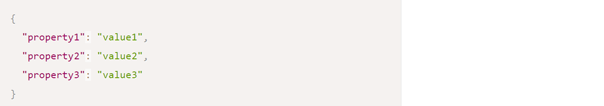

Side Note: It looks like a python dictionary. But just to be clear: JSON is a data format (a string), Python dictionary is a data structure (in-memory object).

## 2) The Method

The method is the type of request you send to the server. You can choose from these five types below:

- **GET:** This request is used to get a resource from a server. If you perform a `GET` request, the server looks for the data you requested and sends it back to you. In other words, a `GET` request performs a `READ` operation. This is the default request method.
- **POST:** This request is used to create a new resource on a server. If you perform a `POST` request, the server creates a new entry in the database and tells you whether the creation is successful. In other words, a `POST` request performs an `CREATE` operation.
- **PUT and PATCH:** These two requests are used to update a resource on a server. If you perform a `PUT` or `PATCH` request, the server updates an entry in the database and tells you whether the update is successful. In other words, a `PUT` or `PATCH` request performs an `UPDATE` operation.
- **DELETE:** This request is used to delete a resource from a server. If you perform a `DELETE` request, the server deletes an entry in the database and tells you whether the deletion is successful. In other words, a `DELETE` request performs a `DELETE` operation.

### Examples:

Look at the API Documentation to know what request method to use:

1. A **GET** request is required to get a list of repositories from a user
2. A **POST** request is required to create a new Github repository

You can set the request method in cURL by writing -X or --request, followed by the request method. This command below tries to create a repository via cURL:

- curl -X POST https://api.github.com/user/repos

## 3) The Headers

Headers are used to provide information to both the client and server. It can be used for many purposes, such as authentication and providing information about the body content.

You can send HTTP headers with curl through the -H or --header option. To send the above header to Github’s API, you use this command:

- *curl -H "Content-Type: application/json" https://api.github.com*

To view headers you’ve sent, you can use the -v or --verbose option as you send the request, like this:

- *curl -H "Content-Type: application/json" https://api.github.com -v*

## 4) The Data (Or “Body”)

It contains information you want to be sent to the server. This option is only used with POST, PUT, PATCH or DELETE requests.

To send data through cURL, you can use the -d or --data option:

- *curl -X POST -d property1=value1*

To send multiple data fields, you can create multiple -d options:

- *curl -X POST -d property1=value1 -d property2=value2*

If it makes sense, you can break your request into multiple lines \ to make it easier to read:

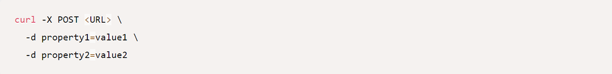

## Authentication

Since POST, PUT, PATCH and DELETE requests alter the database, developers almost always put them behind an authentication wall. In some cases, a GET request also requires authentication (like when you access your bank account to check your current balance, for example).

On the web, there are two main ways to authenticate yourself:

- With a username and password (also called basic authentication)
- With a secret token

The secret token method includes oAuth, which lets you to authenticate yourself with social media networks like Github, Google, Twitter, Facebook, etc.

To perform a basic authentication with cURL, you can use the -u option, followed by your username and password, like this:

- *curl -x POST -u "username:password" https://api.github.com/user/repos*

## HTTP Status Codes And Error Messages

HTTP status codes let you tell the status of the response quickly. The range from 100+ to 500+. In general, the numbers follow the following rules:

- 200+ means the request has succeeded.
- 300+ means the request is redirected to another URL
- 400+ means an error that originates from the client has occurred
- 500+ means an error that originates from the server has occurred

You can debug the status of a response with the verbose option (-v or --verbose) or the head option (-I or --head).

## API Versions

Developers update their APIs from time to time. Sometimes, the API can change so much that the developer decides to upgrade their API to another version. If this happens, and your application breaks, it’s usually because you’ve written code for an older API, but your request points to the newer API.

You can request for a specific API version in two ways. Which way you choose depends on how the API is written.

These two ways are:

1. Directly in the endpoint, e.g.: https://api.twitter.com/1.1/account/settings.json
2. In a request header, e.g. curl https://api.github.com -H Accept:application/vnd.github.v3+json